# Accessing and mapping EMODnet data

## Introduction

The package was designed to make EMODnet vector data layers easily accessible in R. The package allows users to query information on and download data from all available [EMODnet Web Feature Service (WFS) endpoints](https://emodnet.ec.europa.eu/geonetwork/srv/eng/catalog.search) directly into their R working environment. Data are managed as [`sf` objects](https://r-spatial.github.io/sf/) which are currently the state-of-the-art in handling of vector spatial data in R. The package also allows user to specify the coordinate reference system of imported data.

## Installation

You can install the development version of emodnet.wfs from GitHub with:

```r
pak::pak("EMODnet/emodnet.wfs")
```

## Explore the EMODnet WFS services with R

For this tutorial we will make use of the [`sf`](https://r-spatial.github.io/sf/) and [`mapview`](https://r-spatial.github.io/mapview/) packages. The simple features `sf` package is a well known standard for dealing with geospatial vector data. To visualize geometries, `mapview` will create quick interactive maps.

Run this line to install these packages:

```r
install.packages(c("sf", "mapview"))
```

EMODnet is organized into [seven thematic lots](https://emodnet.ec.europa.eu/en/emodnet-themes): Bathymetry, Geology, Seabed Habitats, Chemistry, Biology, Physics, and Human Activities, each focusing on a specific aspect of marine data. With the emodnet.wfs package, we can explore and combine the data served by the EMODnet thematic lots through [OGC Web Feature Services](https://en.wikipedia.org/wiki/Web_Feature_Service) or WFS.

Imagine we are interested in seabed substrates. The first step is to choose what EMODnet thematic lot can provide with these data. For that, we can check the services available with the `emodnet_wfs()` function.

```r
library(emodnet.wfs)
library(mapview)
library(sf)

services <- emodnet_wfs()
class(services)
```

```
#> [1] "tbl_df"     "tbl"        "data.frame"
```

```r
names(services)
```

```
#> [1] "emodnet_thematic_lot" "service_name"         "service_url"
```

```r
services[, c("emodnet_thematic_lot", "service_name")]
```

```
#> # A tibble: 17 × 2
#>    emodnet_thematic_lot     service_name
#>    <chr>                    <chr>
#>  1 EMODnet Bathymetry       bathymetry
#>  2 EMODnet Biology          biology
#>  3 EMODnet Biology          biology_occurrence_data
#>  4 EMODnet Chemistry        chemistry_cdi_data_discovery_and_access_service
#>  5 EMODnet Chemistry        chemistry_cdi_distribution_observations_per_category_and_region
#>  6 EMODnet Chemistry        chemistry_contaminants
#>  7 EMODnet Chemistry        chemistry_marine_litter
#>  8 EMODnet Geology          geology_coastal_behavior
#>  9 EMODnet Geology          geology_events_and_probabilities
#> 10 EMODnet Geology          geology_marine_minerals
#> 11 EMODnet Geology          geology_sea_floor_bedrock
#> 12 EMODnet Geology          geology_seabed_substrate_maps
#> 13 EMODnet Geology          geology_submerged_landscapes
#> 14 EMODnet Human Activities human_activities
#> 15 EMODnet Physics          physics
#> 16 EMODnet Seabed Habitats  seabed_habitats_general_datasets_and_products
#> 17 EMODnet Seabed Habitats  seabed_habitats_individual_habitat_map_and_model_datasets
```

EMODnet data covers several disciplines organized in 7 thematic lots: bathymetry, biology, chemistry, geology, human activities, physics, seabed habitats. Some thematic lots organize their data in more than one data source or service. The column `service_name` shows services available, while `service_url` has the corresponding base url to perform a WFS request. The Seabed portal should have the data we are looking for. A WFS client can be created by passing the corresponding `service_name` to the function `emodnet_init_wfs_client()`. The layers available to this WFS client are consulted with `emodnet_get_wfs_info()`.

```r
seabed_wfs_client <- emodnet_init_wfs_client(service = "seabed_habitats_general_datasets_and_products")
```

```
#> Loading ISO 19139 XML schemas...
#> Loading ISO 19115-3 XML schemas...
#> Loading ISO 19139 codelists...
#> ✔ WFS client created successfully
#> ℹ Service: "https://ows.emodnet-seabedhabitats.eu/geoserver/emodnet_open/wfs"
#> ℹ Version: "2.0.0"
```

```r
emodnet_get_wfs_info(wfs = seabed_wfs_client)
```

```
#> # A tibble: 57 × 9
#> # Rowwise:
#>    data_source service_name                      service_url layer_name title abstract class format layer_namespace
#>    <chr>       <chr>                             <chr>       <chr>      <chr> <chr>    <chr> <chr>  <chr>
#>  1 emodnet_wfs seabed_habitats_general_datasets… https://ow… art17_hab… 2013… "Gridde… WFSF… sf     emodnet_open
#>  2 emodnet_wfs seabed_habitats_general_datasets… https://ow… art17_hab… 2013… "Gridde… WFSF… sf     emodnet_open
#>  3 emodnet_wfs seabed_habitats_general_datasets… https://ow… art17_hab… 2013… "Gridde… WFSF… sf     emodnet_open
#>  4 emodnet_wfs seabed_habitats_general_datasets… https://ow… art17_hab… 2013… "Gridde… WFSF… sf     emodnet_open
#>  5 emodnet_wfs seabed_habitats_general_datasets… https://ow… art17_hab… 2013… "Gridde… WFSF… sf     emodnet_open
#>  6 emodnet_wfs seabed_habitats_general_datasets… https://ow… art17_hab… 2013… "Gridde… WFSF… sf     emodnet_open
#>  7 emodnet_wfs seabed_habitats_general_datasets… https://ow… art17_hab… 2013… "Gridde… WFSF… sf     emodnet_open
#>  8 emodnet_wfs seabed_habitats_general_datasets… https://ow… art17_hab… 2013… "Gridde… WFSF… sf     emodnet_open
#>  9 emodnet_wfs seabed_habitats_general_datasets… https://ow… carib_eus… 2023… "Output… WFSF… sf     emodnet_open
#> 10 emodnet_wfs seabed_habitats_general_datasets… https://ow… biogenic_… Biog… "This l… WFSF… sf     emodnet_open
#> # ℹ 47 more rows
```

Each layer is explained in the `abstract` column. We can see several layers with the information provided by the EU member states for the [Habitats Directive 92/43/EEC reporting](https://www.eea.europa.eu/data-and-maps/data/article-17-database-habitats-directive-92-43-eec-2). We will select the layers about coastal lagoons, mudflats and sandbanks with their respective `layer_name`.

```r
habitats_directive_layer_names <- c("art17_hab_1110", "art17_hab_1140", "art17_hab_1150")

emodnet_get_layer_info(
  wfs = seabed_wfs_client,
  layers = habitats_directive_layer_names
)
```

```
#> # A tibble: 3 × 9
#> # Rowwise:
#>   data_source service_name                       service_url layer_name title abstract class format layer_namespace
#>   <chr>       <chr>                              <chr>       <chr>      <chr> <chr>    <chr> <chr>  <chr>
#> 1 emodnet_wfs https://ows.emodnet-seabedhabitat… seabed_hab… art17_hab… 2013… "Gridde… WFSF… sf     emodnet_open
#> 2 emodnet_wfs https://ows.emodnet-seabedhabitat… seabed_hab… art17_hab… 2013… "Gridde… WFSF… sf     emodnet_open
#> 3 emodnet_wfs https://ows.emodnet-seabedhabitat… seabed_hab… art17_hab… 2013… "Gridde… WFSF… sf     emodnet_open
```

```r
habitats_directive_layers <- emodnet_get_layers(
  wfs = seabed_wfs_client,
  layers = habitats_directive_layer_names,
  simplify = TRUE,
  outputFormat = "application/json"
)

habitats_directive_layers
```

```
#> Simple feature collection with 221 features and 8 fields
#> Geometry type: MULTIPOLYGON
#> Dimension:     XY
#> Bounding box:  xmin: 950000 ymin: 940000 xmax: 6510000 ymax: 4820000
#> Projected CRS: ETRS89-extended / LAEA Europe
#> First 10 features:
#>                   id habitat_code ms region cs_ms   country_code
#> 1  art17_hab_1110.13         1110 DK    ATL   U2+        Denmark
#> 2  art17_hab_1110.22         1110 ES    MAC   U1+          Spain
#> 3  art17_hab_1110.25         1110 ES   MMAC   U1+          Spain
#> 4  art17_hab_1110.59         1110 PT   MMAC    XX       Portugal
#> 5  art17_hab_1110.56         1110 PT   MATL   U1-       Portugal
#> 6  art17_hab_1110.53         1110 PL   MBAL   U1-         Poland
#> 7  art17_hab_1110.17         1110 DK   MBAL   U1-        Denmark
#> 8  art17_hab_1110.31         1110 FR   MATL   U1x         France
```

[output cut: 24 more lines]

Note the use of the `outputFormat` argument in this example. This specifies the file type to request from the service, which can influence how the data is loaded into R. By default, the data is provided in the `GML` format with a geometry type of “MULTISURFACE.” However, this geometry type is not widely supported by many software tools, including the `mapview` package. To address this, you can request a different file type, such as GeoJSON, which delivers the geometry as “MULTIPOLYGON”—a format that is more universally compatible. This has been raised before in the [sf community](https://github.com/r-spatial/sf/issues/748).

Run the following code to have a quick look at the layers geometries.

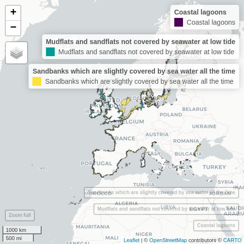

```r
mapview(habitats_directive_layers, zcol = "habitat_description", burst = TRUE)
```

EMODnet provides also physics, chemistry, biological or bathymetry data. Explore all the layers available with:

```r
emodnet_get_all_wfs_info()
```

```
#> # A tibble: 1,782 × 9
#> # Rowwise:
#>    data_source service_name service_url                      layer_name title abstract class format layer_namespace
#>    <chr>       <chr>        <chr>                            <chr>      <chr> <chr>    <chr> <chr>  <chr>
#>  1 emodnet_wfs bathymetry   https://ows.emodnet-bathymetry.… download_… Bath… "Downlo… WFSF… sf     emodnet
#>  2 emodnet_wfs bathymetry   https://ows.emodnet-bathymetry.… contours   Dept… "Genera… WFSF… sf     emodnet
#>  3 emodnet_wfs bathymetry   https://ows.emodnet-bathymetry.… hr_bathym… High… "Layer … WFSF… sf     emodnet
#>  4 emodnet_wfs bathymetry   https://ows.emodnet-bathymetry.… quality_i… Qual… "Repres… WFSF… sf     emodnet
#>  5 emodnet_wfs bathymetry   https://ows.emodnet-bathymetry.… sea_names  Sea … "Mainta… WFSF… sf     world
#>  6 emodnet_wfs bathymetry   https://ows.emodnet-bathymetry.… source_re… Sour… "Covera… WFSF… sf     emodnet
#>  7 emodnet_wfs bathymetry   https://ows.emodnet-bathymetry.… undersea_… unde… ""       WFSF… sf     gebco
#>  8 emodnet_wfs biology      https://geo.vliz.be/geoserver/E… cti_macro… Comm… "Ocean … WFSF… sf     Emodnetbio
#>  9 emodnet_wfs biology      https://geo.vliz.be/geoserver/E… mediseh_c… EMOD… "Coral … WFSF… sf     Emodnetbio
#> 10 emodnet_wfs biology      https://geo.vliz.be/geoserver/E… mediseh_c… EMOD… "Coral … WFSF… sf     Emodnetbio
#> # ℹ 1,772 more rows
```

## More information

### References

Blondel, Emmanuel. (2020, May 27). ows4R: R Interface to OGC Web-Services (Version 0.1-5). Zenodo. https://doi.org/10.5281/zenodo.3860330

Flanders Marine Institute (2019). Maritime Boundaries Geodatabase, version 11. Available online at https://www.marineregions.org/. https://doi.org/10.14284/382.

Hadley Wickham, Romain François, Lionel Henry and Kirill Müller (2020). dplyr: A Grammar of Data Manipulation. R package version 1.0.2.https://CRAN.R-project.org/package=dplyr

Pebesma E (2018). “Simple Features for R: Standardized Support for Spatial Vector Data.” The R Journal, 10(1), 439–446. doi: 10.32614/RJ-2018-009, https://doi.org/10.32614/RJ-2018-009.

R Core Team (2020). R: A language and environment for statistical computing. R Foundation for Statistical Computing, Vienna, Austria. URL https://www.R-project.org/.

Tim Appelhans, Florian Detsch, Christoph Reudenbach and Stefan Woellauer (2020). mapview: Interactive Viewing of Spatial Data in R. R package version 2.9.0. https://CRAN.R-project.org/package=mapview

### Code

To cite emodnet.wfs, please use the output from `citation(package = "emodnet.wfs")`.

```r
citation(package = "emodnet.wfs")
```

```
#>
#>   Krystalli A, Fernández-Bejarano S, Salmon M (????). _emodnet.wfs: Access EMODnet Web Feature Service
#>   data through R_. doi:10.14284/679 <https://doi.org/10.14284/679>, R package version 2.1.0.
#>   Integrated data products created under the European Marine Observation Data Network (EMODnet)
#>   Biology project (EASME/EMFF/2017/1.3.1.2/02/SI2.789013), funded by the by the European Union under
#>   Regulation (EU) No 508/2014 of the European Parliament and of the Council of 15 May 2014 on the
#>   European Maritime and Fisheries Fund, <https://github.com/EMODnet/emodnet.wfs>.
#>
#> A BibTeX entry for LaTeX users is
#>
#>   @Manual{,
#>     title = {{emodnet.wfs}: Access EMODnet Web Feature Service data through R},
#>     author = {Anna Krystalli and Salvador Fernández-Bejarano and Maëlle Salmon},
#>     note = {R package version 2.1.0. Integrated data products created under the European Marine Observation Data Network (EMODnet) Biology project (EASME/EMFF/2017/1.3.1.2/02/SI2.789013), funded by the by the European Union under Regulation (EU) No 508/2014 of the European Parliament and of the C…
#>     url = {https://github.com/EMODnet/emodnet.wfs},
#>     doi = {10.14284/679},
#>   }
```